# final

b06208016楊鎧綾

January 9, 2019

# 1

## 1.4

### (1)

step.1  
$H_0:$ region have no relationship with use social networking, they are independent  
$H_a:$ region have relationship with use social networking, they are dependent

step.2 the sample is big enough, all of them are bigger than 1, and at least 80% of them bigger than 5

```r
use=c(264,410,287,961)
not=c(54,122,264,440)
TOTAL=c(318,532,551,1401)
a=data.frame(use,not,TOTAL,row.names = c('region_a','region_b','region_c','total'))
a
```

```
##          use not TOTAL
## region_a 264  54   318
## region_b 410 122   532
## region_c 287 264   551
## total    961 440  1401
```

calculate the chi-squared is 118.1388

```r
exp_use=c((a[1,3]*a[4,1]/a[4,3]),(a[2,3]*a[4,1]/a[4,3]),(a[3,3]*a[4,1]/a[4,3]))
exp_not=c((a[1,3]*a[4,2]/a[4,3]),(a[2,3]*a[4,2]/a[4,3]),(a[3,3]*a[4,2]/a[4,3]))
exp=data.frame(exp_use,exp_not,row.names = c('region_a','region_b','region_c' ))
exp
```

```
##           exp_use   exp_not
## region_a 218.1285  99.87152
## region_b 364.9193 167.08066
## region_c 377.9522 173.04782
```

```r
a=a[1:3,1:2];a
```

```
##          use not
## region_a 264  54
## region_b 410 122
## region_c 287 264
```

```r
chi=(a-exp)^2/exp;chi
```

```
##                use      not
## region_a  9.646592 21.06903
## region_b  5.569082 12.16338
## region_c 21.887157 47.80354
```

```r
chi=sum(chi)
chi
```

```
## [1] 118.1388
```

step.3 find the p-value is 0

```r
nrow=3
ncol=2
df=(nrow-1)*(ncol-1)
p.value=1-pchisq(chi,df=df)
p.value
```

```
## [1] 0
```

step.4 under 95% confidence level the alpha=0.05,**the p-value is smaller than alpha, so we can reject null hypothesis**  
step.5 **so we can say that region have relationship with use social networking, they are dependent**

### (2)

data in region c

```r
groups=c("use","notuse","total")
observe=c(287,264,551)
expected=c((1/2)*551,(1/2)*551,551)
a=data.frame(groups,observe,expected)
a
```

```
##   groups observe expected
## 1    use     287    275.5
## 2 notuse     264    275.5
## 3  total     551    551.0
```

step.1  
$H_0:$ the percentage of using social networking sites or not is equal $p_1= p_2$  
$H_a:$ the percentage of using social networking sites or not is not equal$p_1 \neq p_2$  
p means the percentage of using social networking sites or not

step.2 the sample is big enough, all of them are bigger than 1, and at least 80% of them bigger than 5,we calculate the chi-square is 0.9600726

```r
c=a[1:2,2]
exp=a[1:2,3]
chi=((c-exp)^2)/exp
chi=sum(chi)
chi
```

```
## [1] 0.9600726
```

step.3  
the degree of freedom is 1  
the p-value is 0.3271686

```r
k=2
df=k-1;df
```

```
## [1] 1
```

```r
p.value=1-pchisq(chi,df=df)
p.value
```

```
## [1] 0.3271686
```

step.4 under the confidence level of 95% we get the $\alpha=0.05$ ,**the p-value is larger than alpha, it is not significant, so we cannot reject null hypothesis**  
step.5 **so we can say that the percentage of using social networking sites or not is equal**

## 1.5

### (1)

```r
weight = c(176,212,188,206,200,184,193,209,
           187,193,184,198,210,199,180,195,
           164,203,180,187,223,196,189,211)
program = c("pr1", "pr1", "pr1", "pr1", "pr1", "pr1", "pr1","pr1",
            "pr2", "pr2", "pr2", "pr2", "pr2", "pr2", "pr2", "pr2",
            "pr3", "pr3", "pr3", "pr3","pr3", "pr3", "pr3", "pr3")
month=c("month1","month1","month1","month1","month2","month2","month2","month2",
        "month1","month1","month1","month1","month2","month2","month2","month2",
        "month1","month1","month1","month1","month2","month2","month2","month2"
        )
program = factor(program, levels = c("pr1", "pr2", "pr3"))
month = factor(month, levels = c("month1", "month2"))
```

step.1  
$H_0:$ there are no difference between salesperson, that is $\mu_1 = \mu_2 = \mu_3$  
$H_a:$ there are difference between salesperson, that is $\mu_1 \neq \mu_2 \neq \mu_3$(at least one of them is different from others)  
$\mu$ means the mean of the earning of a salesperson

step.2 the data do not have outlier and extreme skewed,  
and the max sd is smaller than two times the min sd, we can calculate the f-value which is 0.079

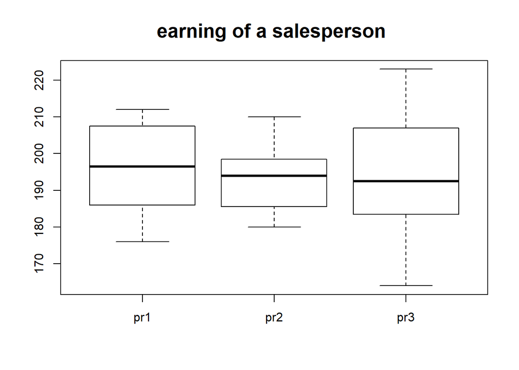

```r
boxplot(weight ~ program,
        main = "earning of a salesperson ", cex.main = 1.6)
```

```r
sd1=sd(c(176,212,188,206,200,184,193,209))
sd2=sd(c(187,193,184,198,210,199,180,195))
sd3=sd(c(164,203,180,187,223,196,189,211))
sd1;sd2;sd3
```

```
## [1] 12.8619
```

```
## [1] 9.558093
```

```
## [1] 18.45796
```

step.3 as the data shows the p-value is 0.924

```r
aa = aov(weight ~ program)
summary(aa)
```

```
##             Df Sum Sq Mean Sq F value Pr(>F)
## program      2     32   15.79   0.079  0.924
## Residuals   21   4182  199.16
```

step.4 under 95% confidence level $\alpha=0.05$, the p-value is larger than alpha, so we cannot reject $H_0$  
step.5 **we can say that there are no difference between salesperson**

### (2)

step.1  
$H_0:$ the weekly earnings are not related to either salesperson or months  
$H_a:$ the weekly earnings are related to either salesperson or months

step.2 the data do not have outlier and extreme skewed,  
and the max sd is smaller than two times the min sd,as the first part(1) show  
we can calculate the f-value of interaction which is 1.265  
step.3 as the data shows the p-value is 0.306  
step.4 under 95% confidence level $\alpha=0.05$, the p-value is larger than alpha(no matter it is salesperson, month, or interaction), so we cannot reject $H_0$  
step.5 **we can say that the weekly earnings are not related to either salesperson or months**

```r
twoway = aov(weight ~ program + month + program:month)
summary(twoway)
```

```
##               Df Sum Sq Mean Sq F value Pr(>F)
## program        2     32    15.8   0.088  0.916
## month          1    513   513.4   2.873  0.107
## program:month  2    452   226.1   1.265  0.306
## Residuals     18   3217   178.7
```

## 1.1

### (1)

```r
heightfoot=read.csv("heightfoot.csv",sep=",",header=T) #read csv
heightfoot=na.omit(heightfoot)#DELETE NA
```

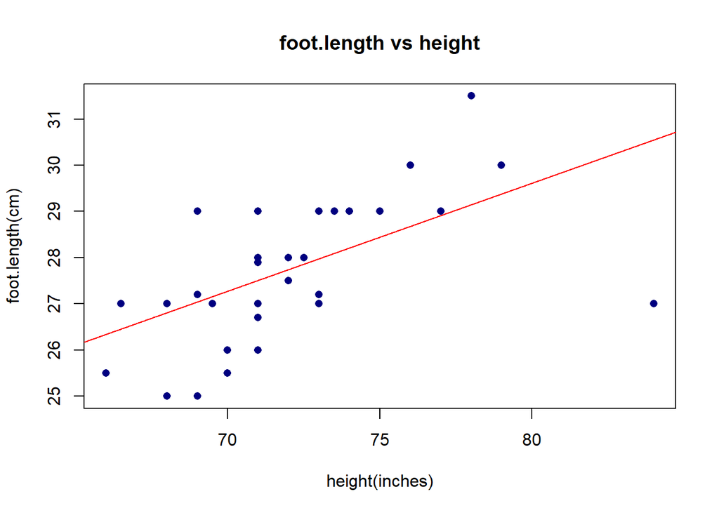

```r
height=heightfoot$height
foot.length=heightfoot$foot.length
RESULTS=lm(foot.length~height)
plot(foot.length~height,pch=16,cex=1,col="navy",main="foot.length vs height",xlab="height(inches)",ylab="foot.length(cm)")
abline(RESULTS,col="red")
```

```r
cor.test(height,foot.length)
```

```
##
##  Pearson's product-moment correlation
##
## data:  height and foot.length
## t = 3.7954, df = 31, p-value = 0.0006428
## alternative hypothesis: true correlation is not equal to 0
## 95 percent confidence interval:
##  0.2726763 0.7596684
## sample estimates:
##       cor
## 0.5632575
```

```r
height_cm=2.54*height
cor.test(height_cm,foot.length)
```

```
##
##  Pearson's product-moment correlation
##
## data:  height_cm and foot.length
## t = 3.7954, df = 31, p-value = 0.0006428
## alternative hypothesis: true correlation is not equal to 0
## 95 percent confidence interval:
##  0.2726763 0.7596684
## sample estimates:
##       cor
## 0.5632575
```

the correlation coefficient is 0.563, 不管單位為何，因為它只是看兩者的相關性

### (3)

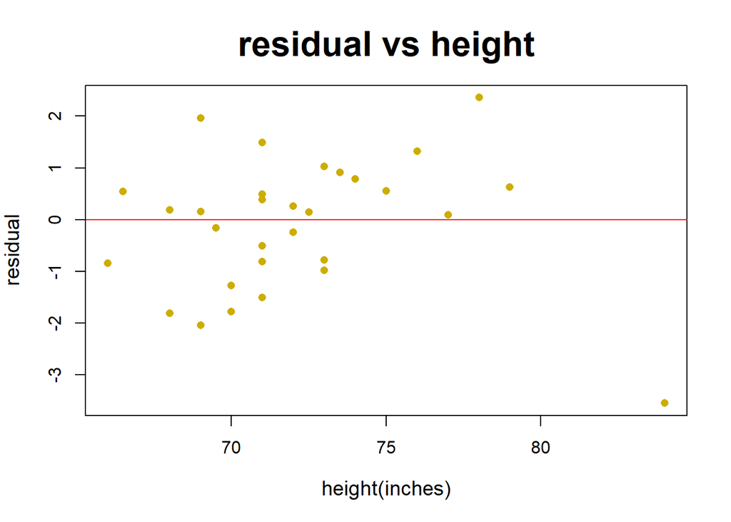

```r
#residuals vs x
res=RESULTS$res
plot(res~height,pch=16,cex=1,col="gold3",main="residual vs height",xlab="height(inches)",ylab="residual",
     cex.main=2,cex.lab=1.2)

abline(h=0,col="red")
```

if we define that residual bigger than three is outlier, there is one outlier which the height is 84

```r
newheightfoot=heightfoot[-28,]
height_n=newheightfoot$height
foot.length_n=newheightfoot$foot.length
cor.test(height_n,foot.length_n)
```

```
##
##  Pearson's product-moment correlation
##
## data:  height_n and foot.length_n
## t = 6.3597, df = 30, p-value = 5.124e-07
## alternative hypothesis: true correlation is not equal to 0
## 95 percent confidence interval:
##  0.5559054 0.8751815
## sample estimates:
##       cor
## 0.7577219
```

the correlation coefficient is 0.7577219,which is higher than part(2), because we remove the outlier who is far away from the path, so the correlation of two variable will be higher

# 2

### (1)

```r
metro=read.csv("metro.csv",sep=",",header=T) #read csv
metro=na.omit(metro)#DELETE NA
```

```r
distance=metro$distance
price=metro$price
RESULTS=lm(price~distance)
coeff=RESULTS$coefficients
coeff
```

```
## (Intercept)    distance
##   70.492346   -0.828631
```

the simple linear regression is **price=-0.8286distance+70.4923**

### (2)

step.1  
$H_0:\beta_1 = 0$  
$H_a:\beta_1 \ne 0$  
$\beta_1$ means the slope of regression line of population which is infered from sample

```r
RESULTS=lm(price~distance)
summary(RESULTS)
```

```
##
## Call:
## lm(formula = price ~ distance)
##
## Residuals:
##     Min      1Q  Median      3Q     Max
## -39.322 -16.024  -6.237  11.294  85.910
##
## Coefficients:
##             Estimate Std. Error t value Pr(>|t|)
## (Intercept)  70.4923     9.4364   7.470 4.06e-11 ***
## distance     -0.8286     0.1988  -4.168 6.83e-05 ***
## ---
## Signif. codes:  0 '***' 0.001 '**' 0.01 '*' 0.05 '.' 0.1 ' ' 1
##
## Residual standard error: 25.22 on 94 degrees of freedom
## Multiple R-squared:  0.156,  Adjusted R-squared:  0.147
## F-statistic: 17.37 on 1 and 94 DF,  p-value: 6.826e-05
```

calculate t-score is -4.168 (by the table above)  
step.3 the p-value is 6.83e-05(by the table above)  
step.4 under the confidence level of 95% , $\alpha=0.05$, the p-value is smaller than 0.05, so we can reject $H_0$, **it is statistically significant**  
step.5 we can say that $\beta_1$ is different from 0,the x variable and y variable has relationship

### (3)

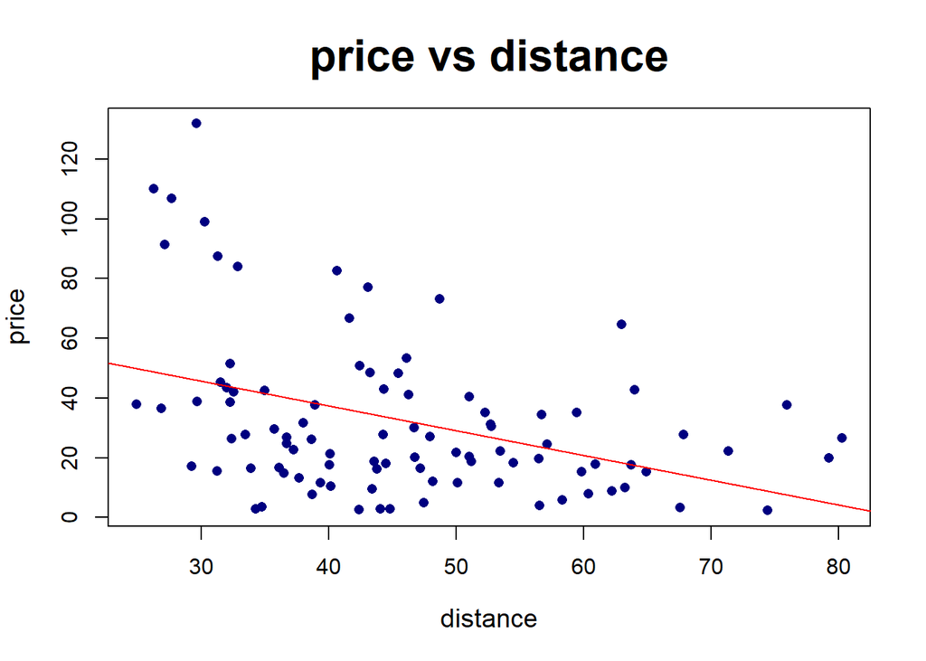

```r
#draw the scatter plot
##y vs x
RESULTS=lm(price~distance)
plot(price~distance,pch=16,cex=1,col="navy",
     main="price vs distance",xlab="distance",ylab="price",cex.main=2,cex.lab=1.2)
abline(RESULTS,col="red")
```

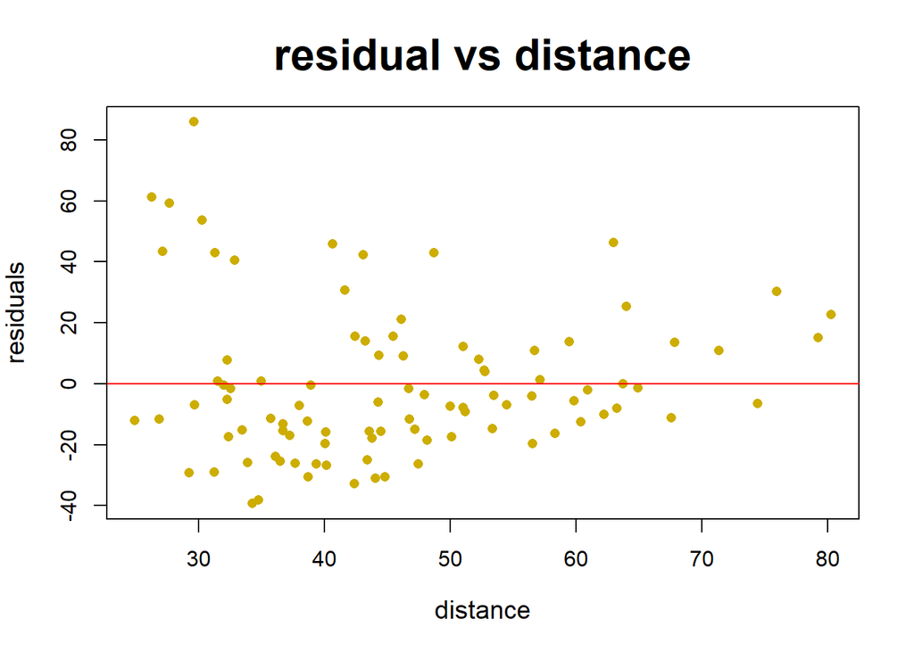

```r
#residuals vs x
res=RESULTS$res
plot(res~distance,pch=16,cex=1,col="gold3",
     main="residual vs distance",xlab="distance",ylab="residuals",
     cex.main=2,cex.lab=1.2)

abline(h=0,col="red")
```

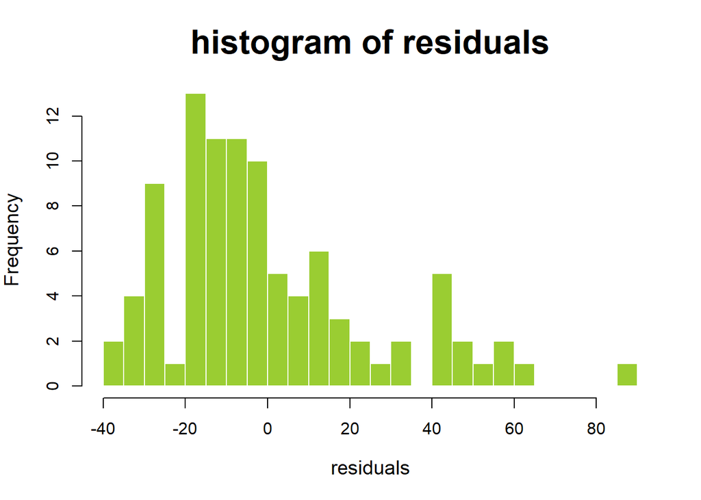

```r
#histogram of residuals
hist(res,breaks=20,border="white",col="olivedrab3",
     main="histogram of residuals", xlab="residuals",
     cex.main=2,cex.lab=1.2)
```

### (4)

```r
#PI
PI=predict(RESULTS,data.frame(distance=c(50)),interval="prediction",level=0.95);PI
```

```
##       fit       lwr      upr
## 1 29.0608 -21.30782 79.42942
```

```r
#CI
CI=predict(RESULTS,data.frame(distance=c(50)),interval="confidence",level=0.95);CI
```

```
##       fit      lwr      upr
## 1 29.0608 23.67092 34.45067
```

the PI means under the confidence level of 95%,if we pick a y under x=specific, it will have the probability of 95% to be in the interval  
,also means 95% of population y might be in the interval,**y的可能範圍,the PI is (-21.3,79.4)**

the CI means under the confidence level of 95%, if we sample a lot of time as x=specific and calculate a mean, the mean would have the probability of 95% to be in the interval,**E(y)的可能範圍, the CI is (23.7,34.5)**  
雖然因為是個體，照理講應該選擇用PI才能代表所有合理的價格範圍，  
但由於房仲做過很多，因此極端值不易被他接受，所以用CI來找出一般大家成交價平均的範圍是比較可行的

# 3

### (1)

```r
weight = c(17,19,15,17,
           25,22,28,
           19,21,19,17)
program = c("pr1", "pr1", "pr1", "pr1",
            "pr2", "pr2", "pr2",
            "pr3", "pr3", "pr3", "pr3")
program = factor(program, levels = c("pr1", "pr2", "pr3"))
```

step.1  
$H_0:$ there are no difference between regions, that is $\mu_1 = \mu_2 = \mu_3$  
$H_a:$ there are difference between regions, that is $\mu_1 \neq \mu_2 \neq \mu_3$(at least one of them is different from others)  
$\mu$ means the mean of the renting time of a region

step.2 the data do not have outlier and extreme skewed,  
and the max sd is smaller than two times the min sd, we can calculate the f-value which is 13.52

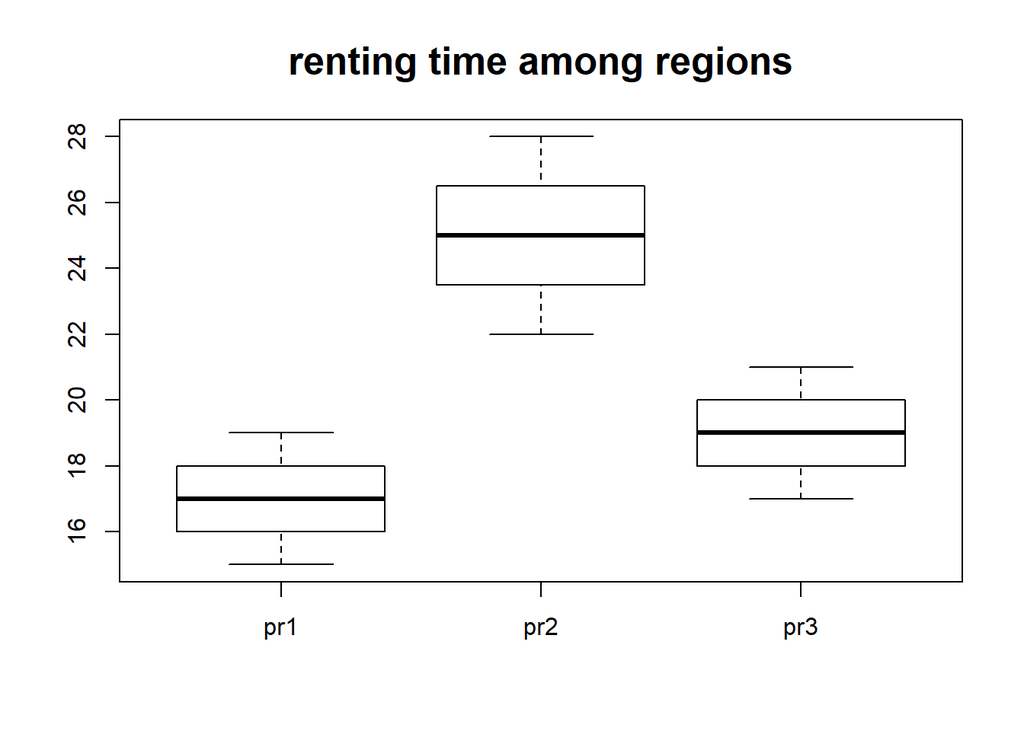

```r
boxplot(weight ~ program,
        main = "renting time among regions", cex.main = 1.6)
```

```r
sd1=sd(c(17,19,15,17))
sd2=sd(c(25,22,28))
sd3=sd(c(19,21,19,17))
sd1;sd2;sd3
```

```
## [1] 1.632993
```

```
## [1] 3
```

```
## [1] 1.632993
```

step.3 as the data shows the p-value is 0.00272

```r
aa = aov(weight ~ program)
summary(aa)
```

```
##             Df Sum Sq Mean Sq F value  Pr(>F)
## program      2  114.9   57.45   13.52 0.00272 **
## Residuals    8   34.0    4.25
## ---
## Signif. codes:  0 '***' 0.001 '**' 0.01 '*' 0.05 '.' 0.1 ' ' 1
```

step.4 under 95% confidence level $\alpha=0.05$, the p-value is smaller than alpha, so we can reject $H_0$  
step.5 **we can say that depend on different rejions the renting time of bike might be different**

### (2)

the sample is small, but it is not extreme skewed and do not have outlier, so we can calculate the confidence interval

```r
group2=c(25,22,28)
mean=mean(group2)
sd=sd(group2)
t=qt(0.025,lower.tail = F,df=3-1)
mean-t*sd/sqrt(3)
```

```
## [1] 17.54759
```

```r
mean+t*sd/sqrt(3)
```

```
## [1] 32.45241
```

**the 95% confidence interval of mean is (17.54,32.45)**

# 4

### (1)

step.1  
$H_0:$ 支持傾向在不同區域沒有差異  
$H_a:$ 支持傾向在不同區域有差異

step.2 the sample is big enough, all of them are bigger than 1, and at least 80% of them bigger than 5

```r
blue=c(28,26,23,26,103)
green=c(30,25,38,22,115)
white=c(20,22,15,25,82)
TOTAL=c(78,73,76,73,300)
a=data.frame(blue,green,white,TOTAL,row.names = c('north','mid','south','east','total'))
a
```

```
##       blue green white TOTAL
## north   28    30    20    78
## mid     26    25    22    73
## south   23    38    15    76
## east    26    22    25    73
## total  103   115    82   300
```

calculate the chi-squared is 7.96119

```r
exp_blue=c(103*78/300,103*73/300,103*76/300,103*73/300)
exp_green=c(115*78/300,115*73/300,115*76/300,115*73/300)
exp_white=c(82*78/300,82*73/300,82*76/300,82*73/300)
exp=data.frame(exp_blue,exp_green,exp_white,row.names = c('north','mid','south','east' ))
exp
```

```
##       exp_blue exp_green exp_white
## north 26.78000  29.90000  21.32000
## mid   25.06333  27.98333  19.95333
## south 26.09333  29.13333  20.77333
## east  25.06333  27.98333  19.95333
```

```r
a=a[1:4,1:3];a
```

```
##       blue green white
## north   28    30    20
## mid     26    25    22
## south   23    38    15
## east    26    22    25
```

```r
chi=(a-exp)^2/exp;chi
```

```
##             blue        green      white
## north 0.05557879 0.0003344482 0.08172608
## mid   0.03500510 0.3180563828 0.20993206
## south 0.36671095 2.6985507246 1.60452717
## east  0.03500510 1.2793428628 1.27642054
```

```r
chi=sum(chi)
chi
```

```
## [1] 7.96119
```

step.3 find the p-value is 0.2409604

```r
nrow=4
ncol=3
df=(nrow-1)*(ncol-1)
p.value=1-pchisq(chi,df=df)
p.value
```

```
## [1] 0.2409604
```

step.4 under 95% confidence level the alpha=0.05,**the p-value is larger than alpha, so we cannot reject null hypothesis**  
step.5 **so we can say that 支持傾向在不同區域沒有差異**

### (2)

#### 北部

```r
groups=c("blue","green","white")
times=c(28,30,20)
expected=c((1/3)*78,(1/3)*78,(1/3)*78)
a=data.frame(groups,times,expected)
a
```

```
##   groups times expected
## 1   blue    28       26
## 2  green    30       26
## 3  white    20       26
```

step.1  
$H_0:$ 三個政黨支持度相同$p_1= p_2= p_3$  
$H_a:$ 三個政黨支持度不同$p_1 \neq p_2 \neq p_3$  
p means 政黨支持度

step.2 the sample is big enough, all of them are bigger than 1, and at least 80% of them bigger than 5,we calculate the chi-square is 2.153846

```r
c=a[,2]
exp=a[,3]
chi=((c-exp)^2)/exp
chi=sum(chi)
chi
```

```
## [1] 2.153846
```

step.3  
the degree of freedom is 2  
the p-value is 0.340642

```r
k=3
df=k-1;df
```

```
## [1] 2
```

```r
p.value=1-pchisq(chi,df=df)
p.value
```

```
## [1] 0.340642
```

step.4 under the confidence level of 95% we get the $\alpha=0.05$ ,**the p-value is larger than alpha, so we cannot reject null hypothesis**  
step.5 **so we can say that支持傾向在北部區域沒有差異**

#### 中部

```r
groups=c("blue","green","white")
times=c(26,25,22)
expected=c((1/3)*73,(1/3)*73,(1/3)*73)
a=data.frame(groups,times,expected)
a
```

```
##   groups times expected
## 1   blue    26 24.33333
## 2  green    25 24.33333
## 3  white    22 24.33333
```

step.1  
$H_0:$ 三個政黨支持度相同$p_1= p_2= p_3$  
$H_a:$ 三個政黨支持度不同$p_1 \neq p_2 \neq p_3$  
p means 政黨支持度

step.2 the sample is big enough, all of them are bigger than 1, and at least 80% of them bigger than 5,we calculate the chi-square is 0.3561644

```r
c=a[,2]
exp=a[,3]
chi=((c-exp)^2)/exp
chi=sum(chi)
chi
```

```
## [1] 0.3561644
```

step.3  
the degree of freedom is 2  
the p-value is 0.8368736

```r
k=3
df=k-1;df
```

```
## [1] 2
```

```r
p.value=1-pchisq(chi,df=df)
p.value
```

```
## [1] 0.8368736
```

step.4 under the confidence level of 95% we get the $\alpha=0.05$ ,**the p-value is larger than alpha, so we cannot reject null hypothesis**  
step.5 **so we can say that支持傾向在中部區域沒有差異**

#### 南部

```r
groups=c("blue","green","white")
times=c(23,38,15)
expected=c((1/3)*76,(1/3)*76,(1/3)*76)
a=data.frame(groups,times,expected)
a
```

```
##   groups times expected
## 1   blue    23 25.33333
## 2  green    38 25.33333
## 3  white    15 25.33333
```

step.1  
$H_0:$ 三個政黨支持度相同$p_1= p_2= p_3$  
$H_a:$ 三個政黨支持度不同$p_1 \neq p_2 \neq p_3$  
p means 政黨支持度

step.2 the sample is big enough, all of them are bigger than 1, and at least 80% of them bigger than 5,we calculate the chi-square is 10.76316

```r
c=a[,2]
exp=a[,3]
chi=((c-exp)^2)/exp
chi=sum(chi)
chi
```

```
## [1] 10.76316
```

step.3  
the degree of freedom is 2  
the p-value is 0.004600552

```r
k=3
df=k-1;df
```

```
## [1] 2
```

```r
p.value=1-pchisq(chi,df=df)
p.value
```

```
## [1] 0.004600552
```

step.4 under the confidence level of 95% we get the $\alpha=0.05$ ,**the p-value is smaller than alpha, so we can reject null hypothesis**  
step.5 **so we can say that支持傾向在南部區域有差異**

#### 東部

```r
groups=c("blue","green","white")
times=c(26,22,25)
expected=c((1/3)*73,(1/3)*73,(1/3)*73)
a=data.frame(groups,times,expected)
a
```

```
##   groups times expected
## 1   blue    26 24.33333
## 2  green    22 24.33333
## 3  white    25 24.33333
```

step.1  
$H_0:$ 三個政黨支持度相同$p_1= p_2= p_3$  
$H_a:$ 三個政黨支持度不同$p_1 \neq p_2 \neq p_3$  
p means 政黨支持度

step.2 the sample is big enough, all of them are bigger than 1, and at least 80% of them bigger than 5,we calculate the chi-square is 0.3561644

```r
c=a[,2]
exp=a[,3]
chi=((c-exp)^2)/exp
chi=sum(chi)
chi
```

```
## [1] 0.3561644
```

step.3  
the degree of freedom is 2  
the p-value is 0.8368736

```r
k=3
df=k-1;df
```

```
## [1] 2
```

```r
p.value=1-pchisq(chi,df=df)
p.value
```

```
## [1] 0.8368736
```

step.4 under the confidence level of 95% we get the $\alpha=0.05$ ,**the p-value is larger than alpha, so we cannot reject null hypothesis**  
step.5 **so we can say that支持傾向在東部區域沒有差異**  
**政黨支持傾向只有在南部有明顯差異**